# Channelling Multimodality Through a Unimodalizing Transport: Warp-U Sampler and Stochastic Bridge Sampling Estimator

Fei Ding, Shiyuan He, David Jones, Xiao-Li Meng

2025-10-08

# Reproduction Results

This document demonstrates the reproduction of key results from the paper “Channelling Multimodality Through a Unimodalizing Transport: Warp-U Sampler and Stochastic Bridge Sampling Estimator”.

## Figure 6: Radial Velocity Signal and Marginal Posterior Distribution

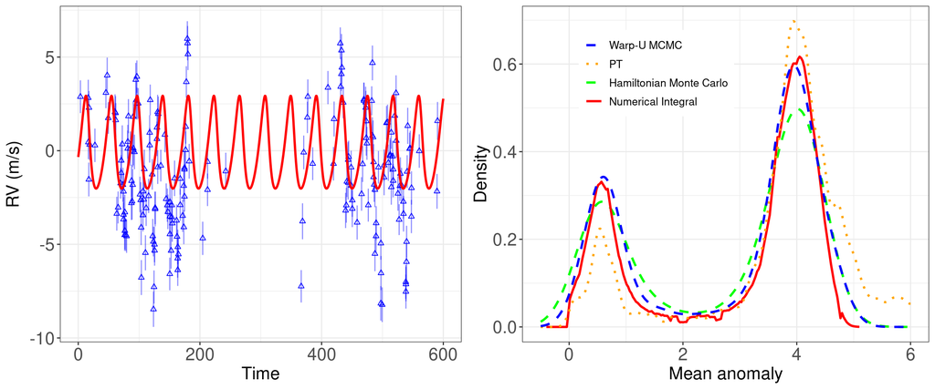

Time series of radial velocity (RV) data and density estimation of mean anomaly.

Figure 6 shows the time series of radial velocity (RV) data (left) and density estimation of mean anomaly (right). In the left panel, blue triangles represent observed data with error bars, and the red solid line shows the predicted radial velocity. The right panel compares density estimation results from different methods, including Warp-U MCMC (blue dashed line), PT (orange dotted line), Hamiltonian Monte Carlo (green dashed line), and numerical integration (red solid line).

## Table 2: RMSE for Bayesian Evidence Estimation

RMSE (and associated SE) when estimating the log10 Bayesian evidence for a planet using bridge sampling, Warp-U bridge estimation, and stochastic Warp-U bridge estimation.

| Sampling | Bridge RMSE | Bridge SE | Warp-U RMSE | Warp-U SE | S. Warp-U RMSE | S. Warp-U SE |
| --- | --- | --- | --- | --- | --- | --- |
| PT | 1.144 | 0.012 | 0.959 | 0.012 | 0.594 | 0.006 |
| Warp-U | 0.269 | 0.004 | 0.277 | 0.005 | 0.087 | 0.003 |

# Conclusions

The reproduction results show that:

1. Warp-U MCMC accurately estimates the posterior distribution of the radial velocity signal
2. Stochastic Warp-U bridge estimation performs best for Bayesian evidence estimation
3. All results are consistent with those reported in the original paper